# CS5801 Coursework Template Proforma

Boxplots:

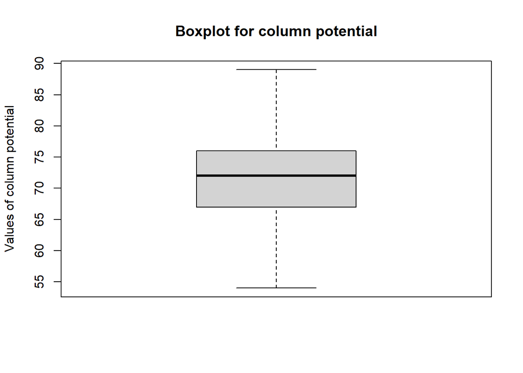

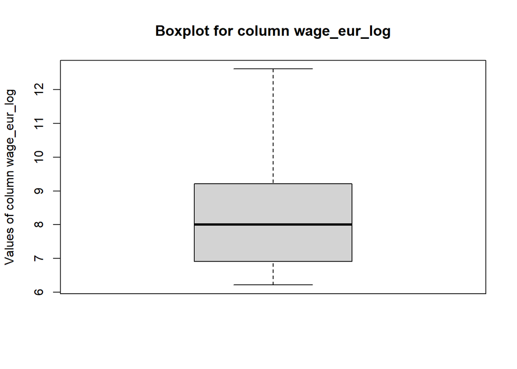

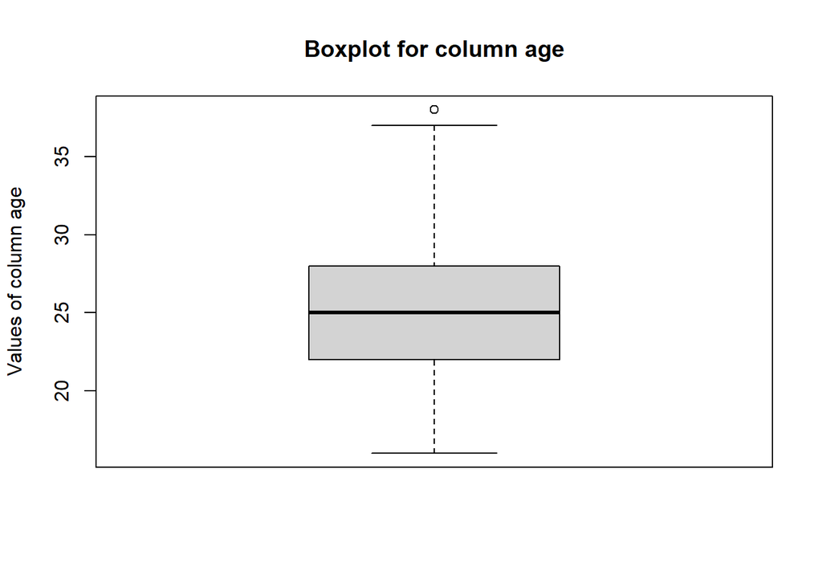

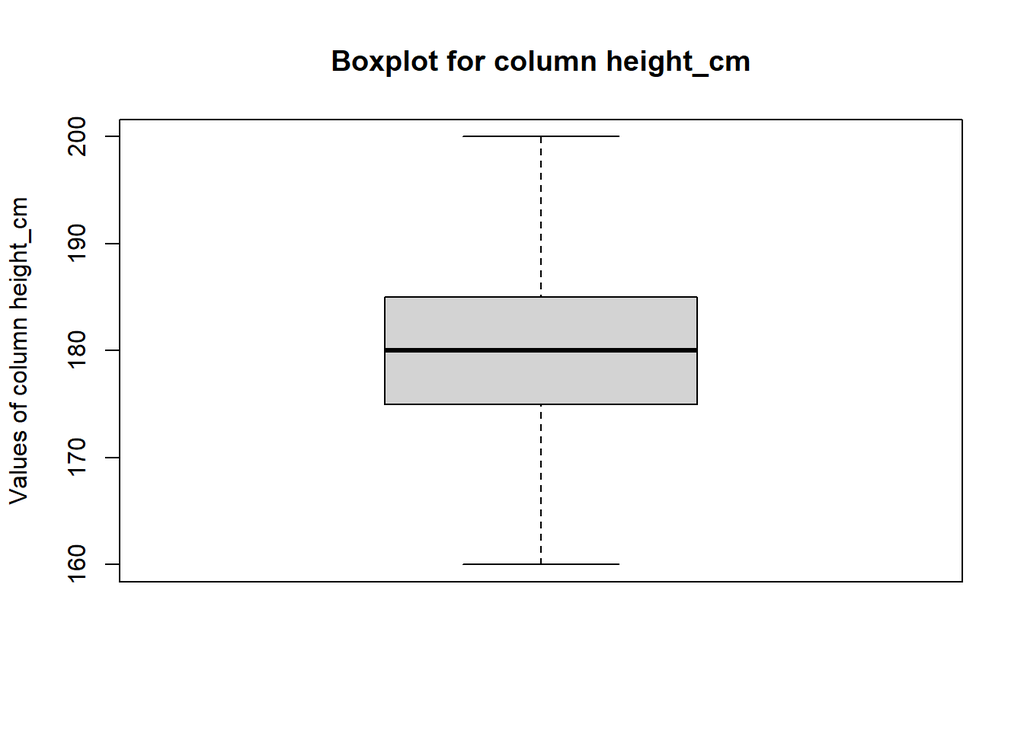

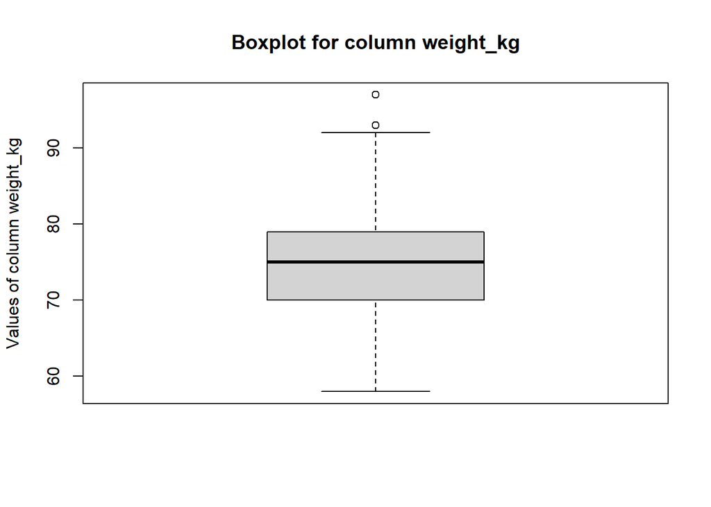

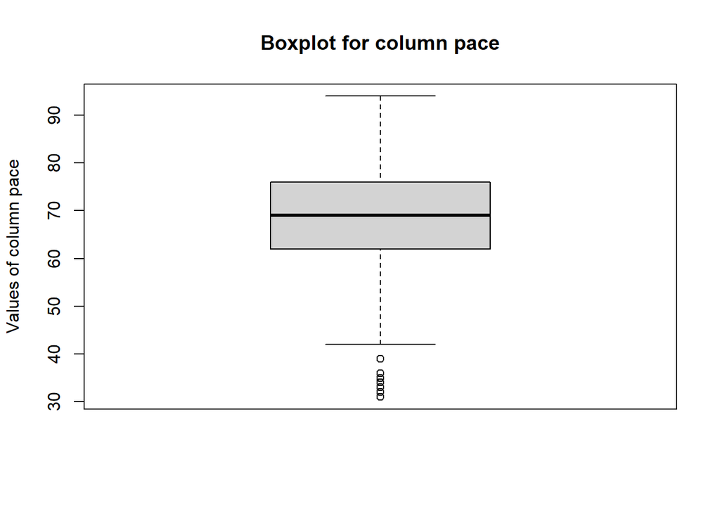

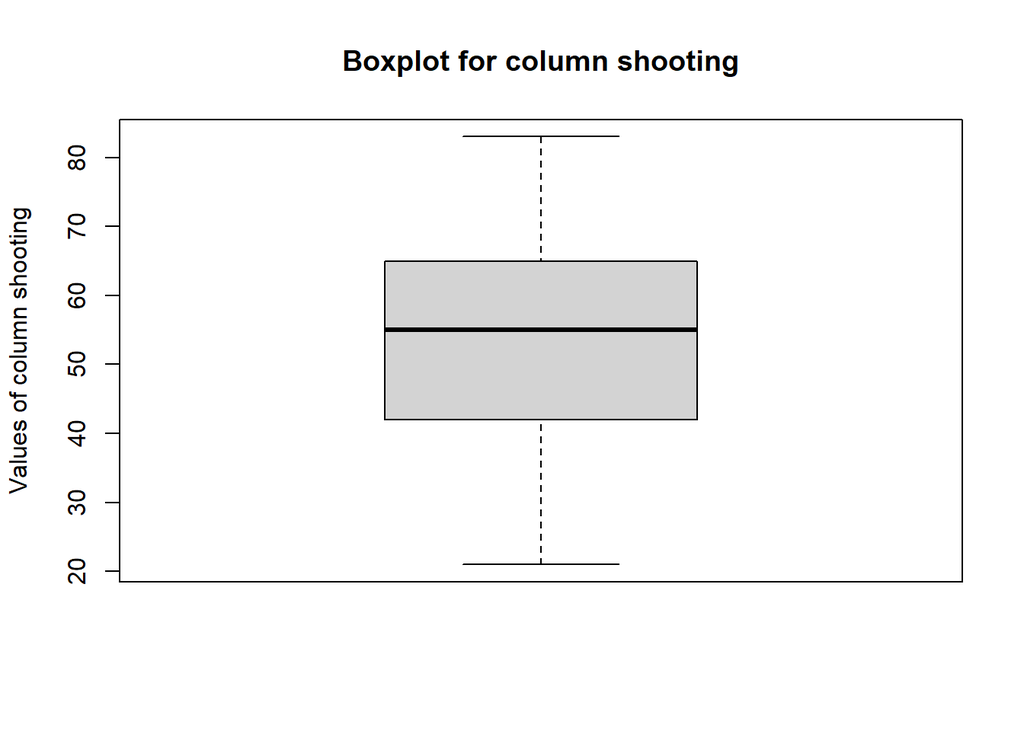

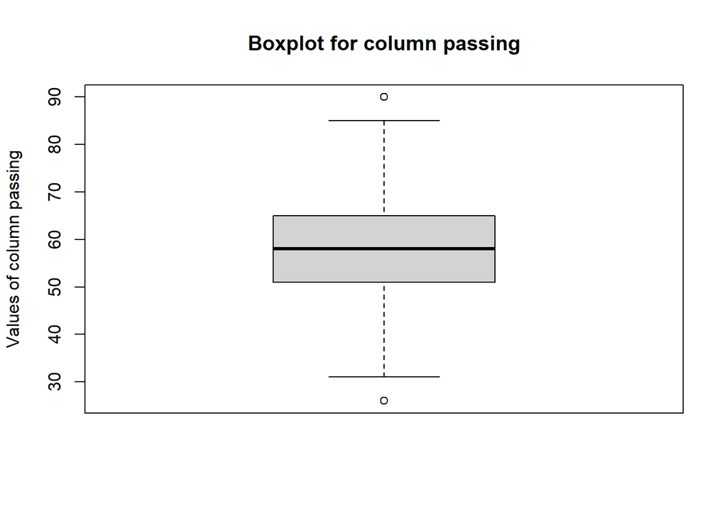

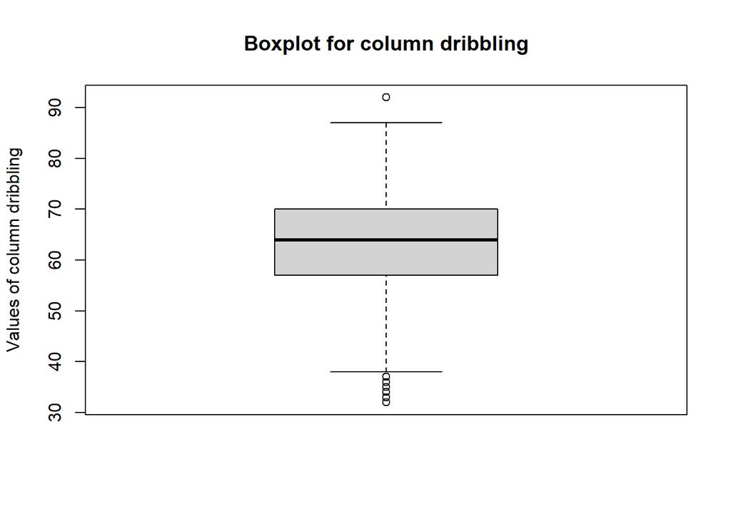

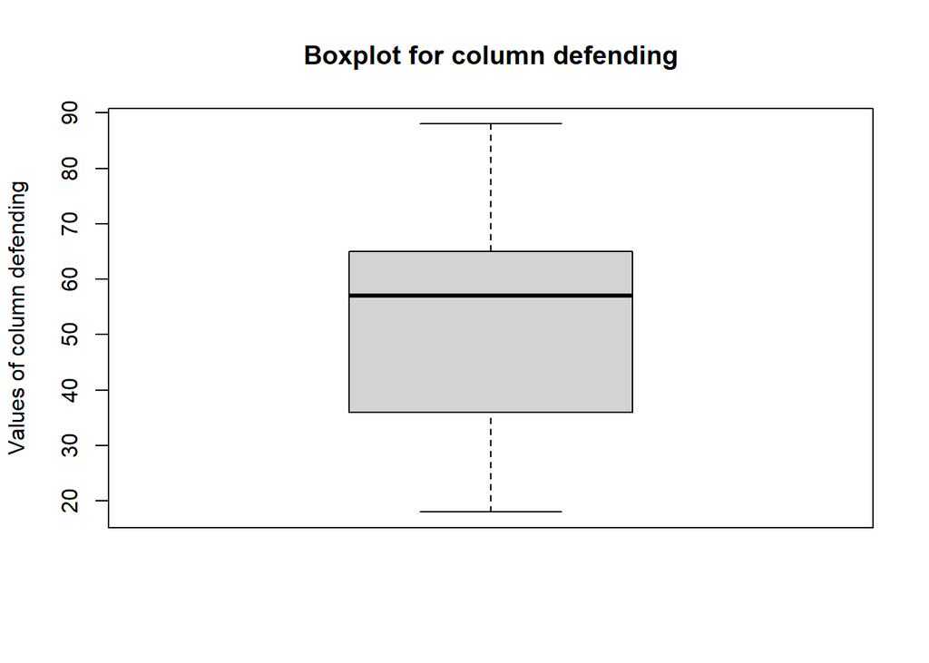

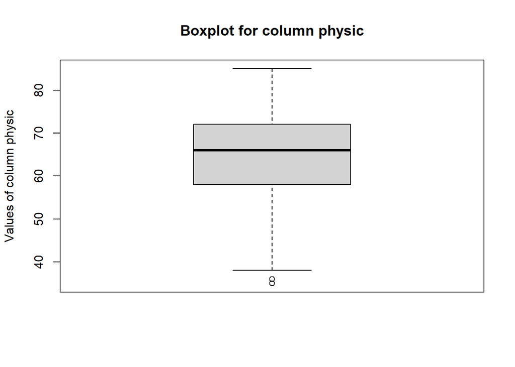

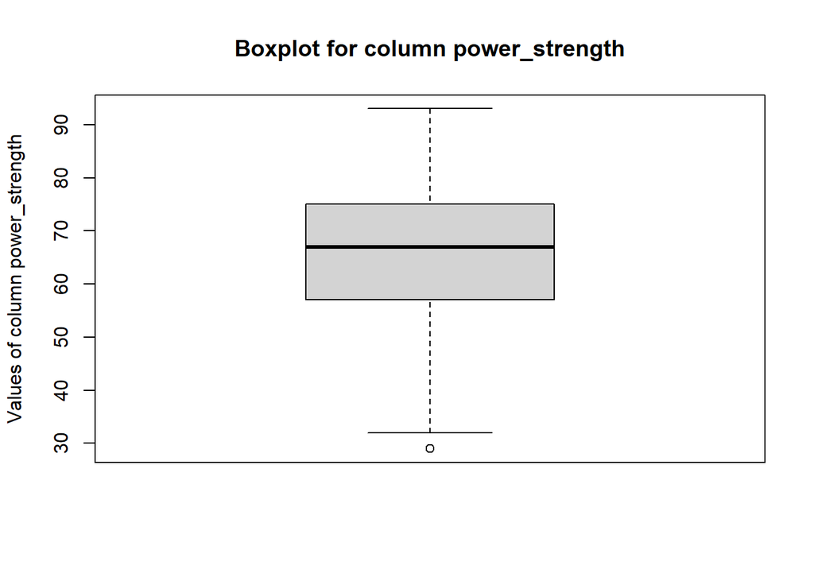

[1 more figures not shown]

```r
for (col in numeric_columns){
  title = paste("Boxplot for column", col)
  y_axis = paste("Values of column", col)
  boxplot(df[, col], main=title, ylab=y_axis)
}
```

- Even though the boxplots show that some columns do have outliers, those outliers do not represent any trouble when modeling as they seem to land on the range of normal values given by FIFA.

Now, we need to explored the categorical columns. First, wee need to create tables.

```r
table_foot <- table(df$preferred_foot)
print(table_foot)
```

```
##
##  Left Right
##   121   393
```

```r
table_wage <- table(df$high.wage.ind)
print(table_wage)
```

```
##
##   0   1
## 365 149
```

Now, we will create barplots

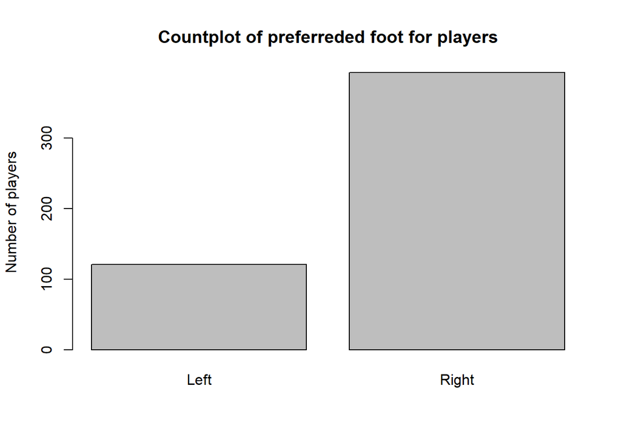

```r
barplot(table_foot,
        names.arg=rownames(table_foot),
        ylab="Number of players",
        main="Countplot of preferreded foot for players")
```

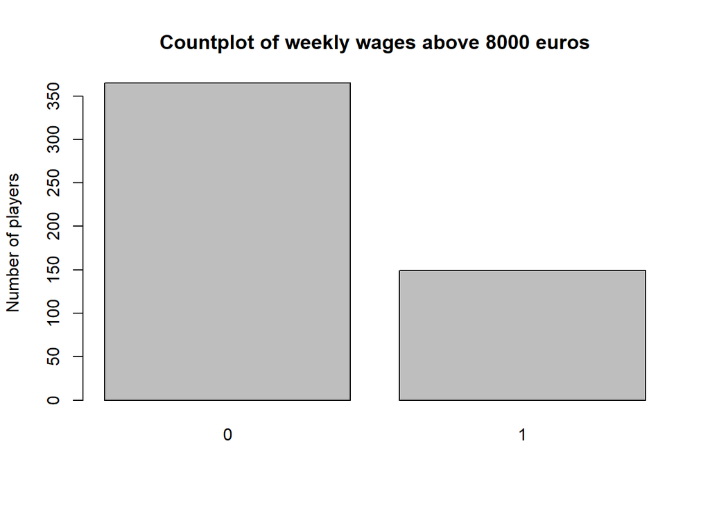

```r
barplot(table_wage,
        names.arg=rownames(table_wage),
        ylab="Number of players",
        main="Countplot of weekly wages above 8000 euros")
```

- It is clearly shown that both categorical columns are not balanced.

### Bivariate EDA

**Regarding column `potential`**

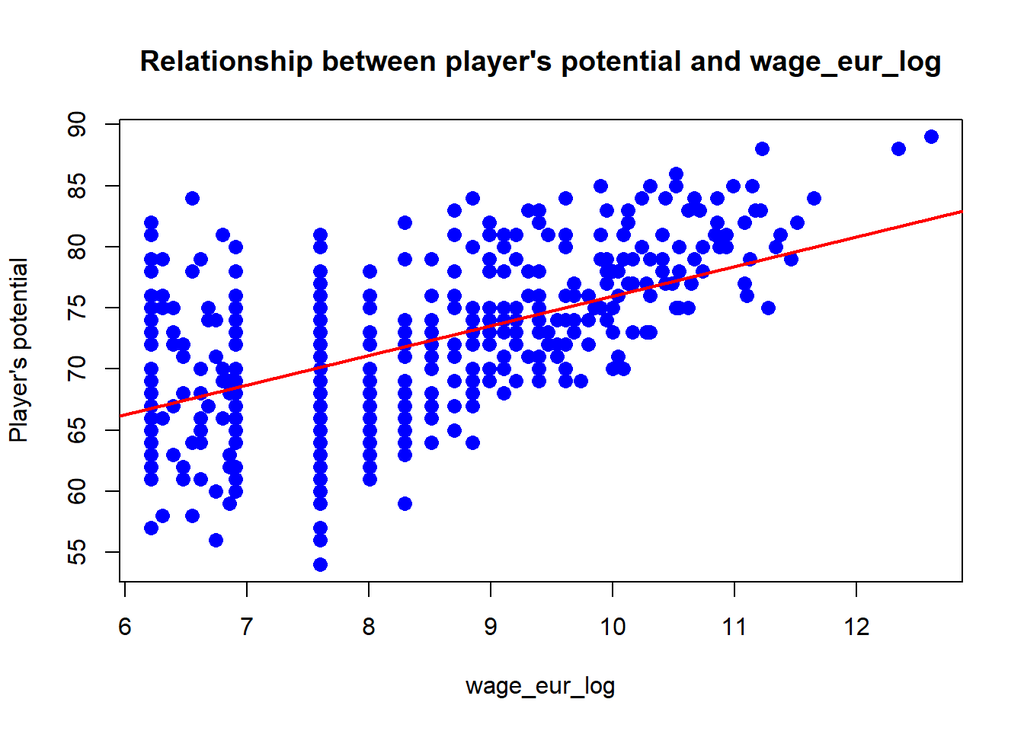

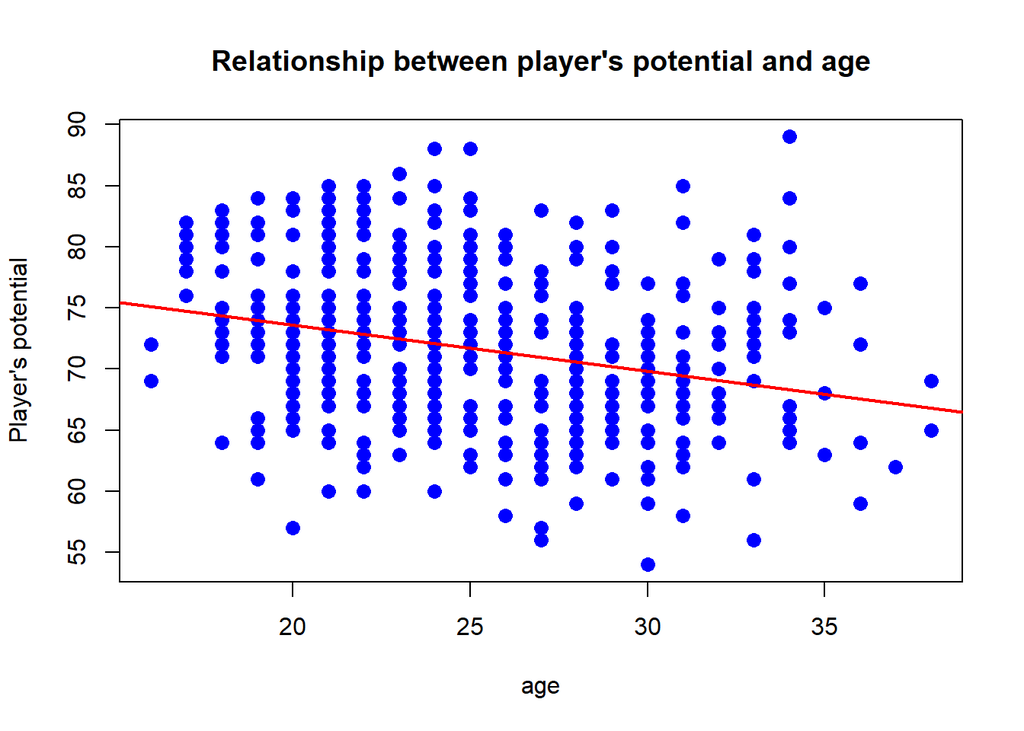

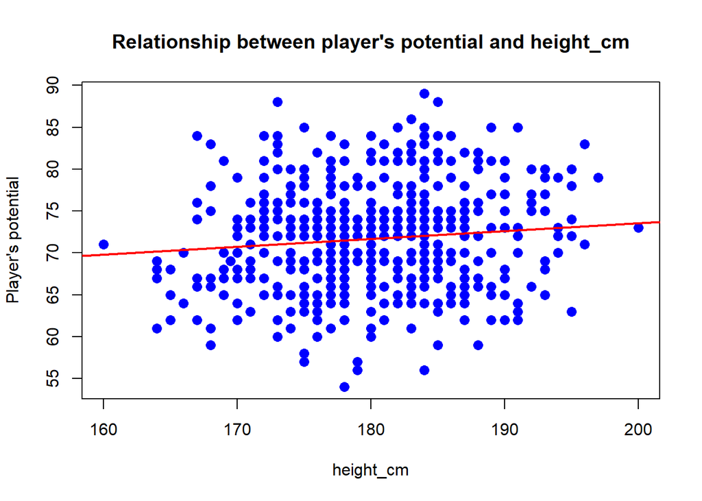

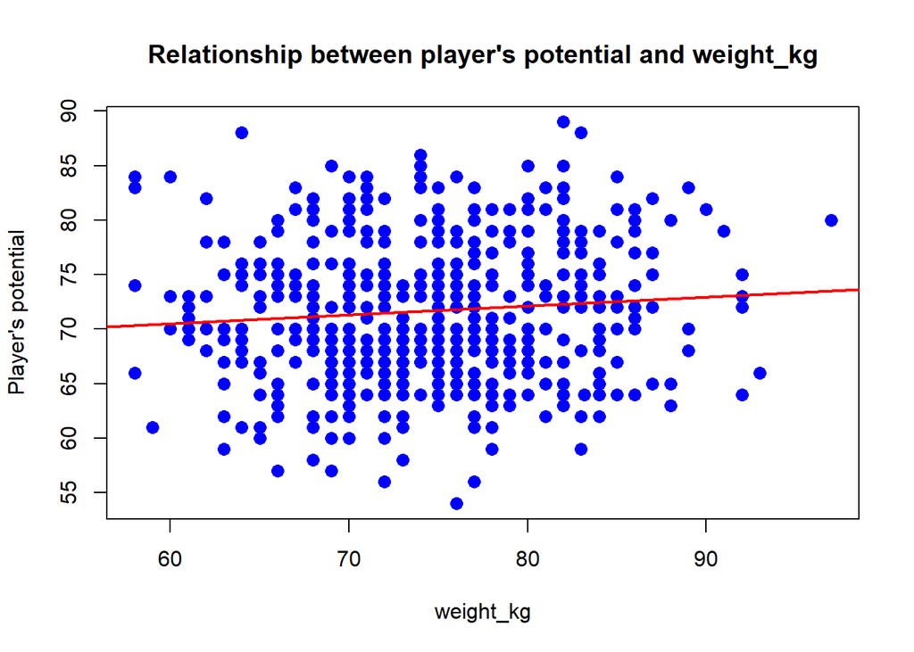

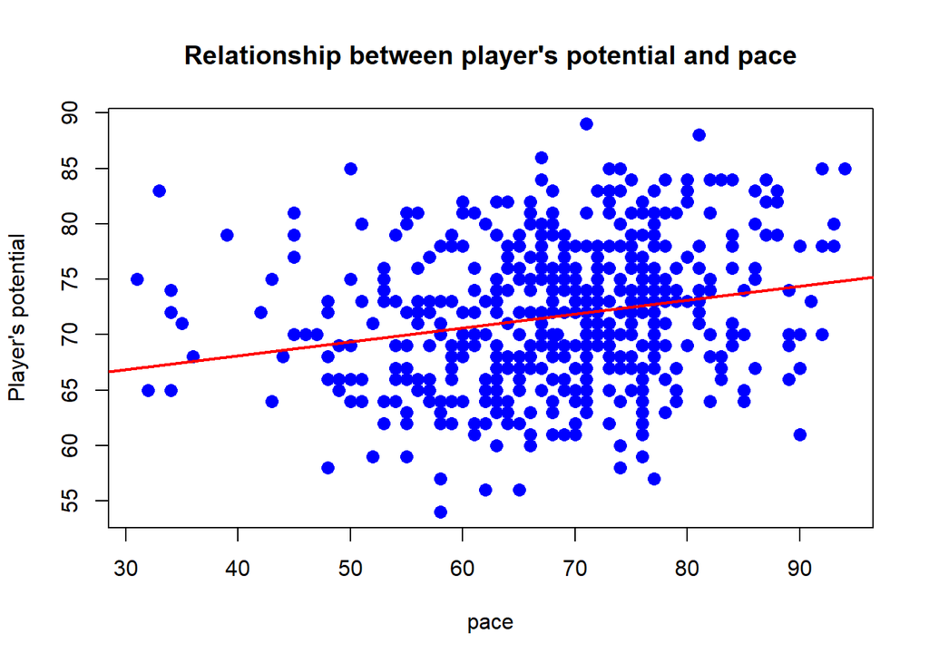

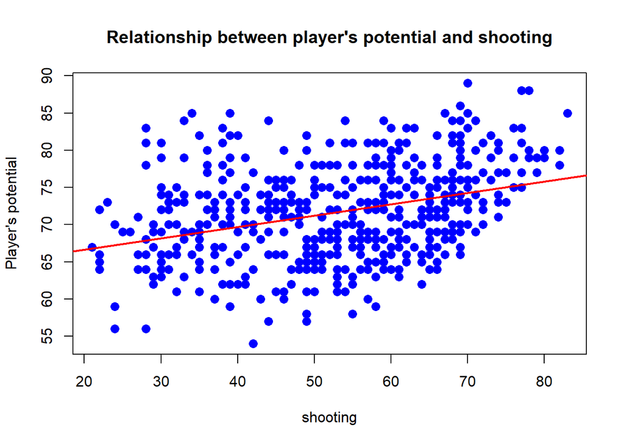

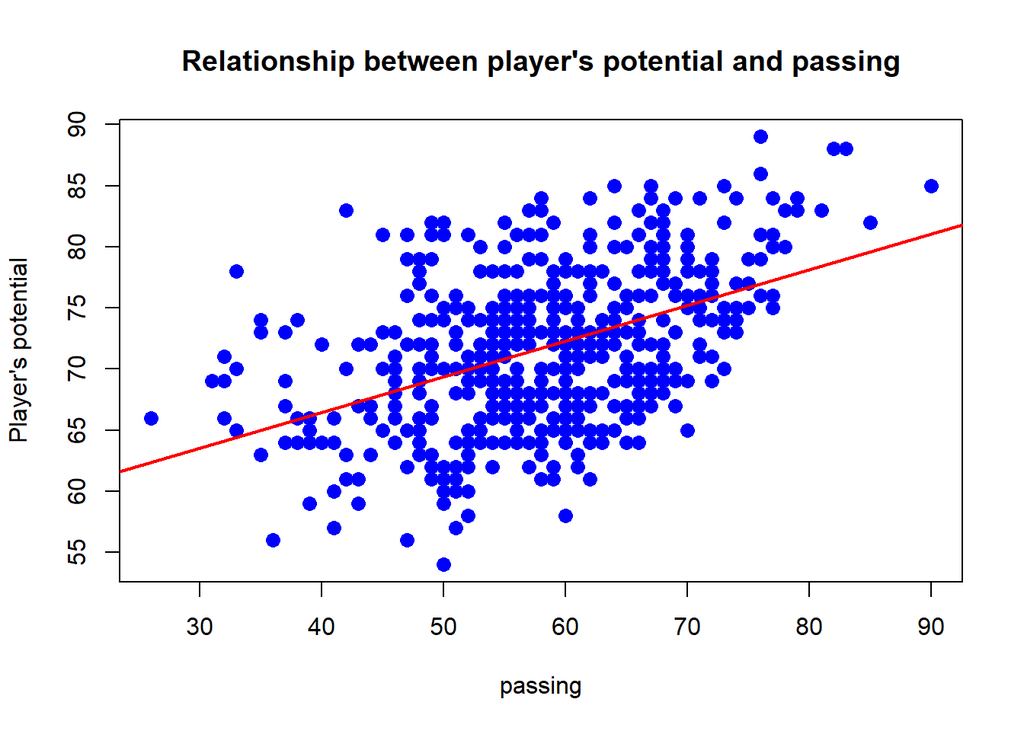

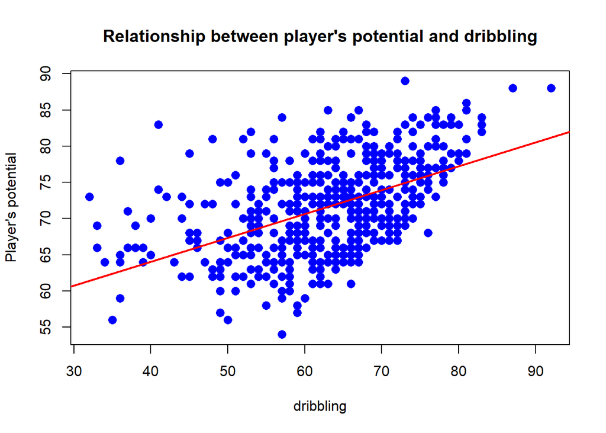

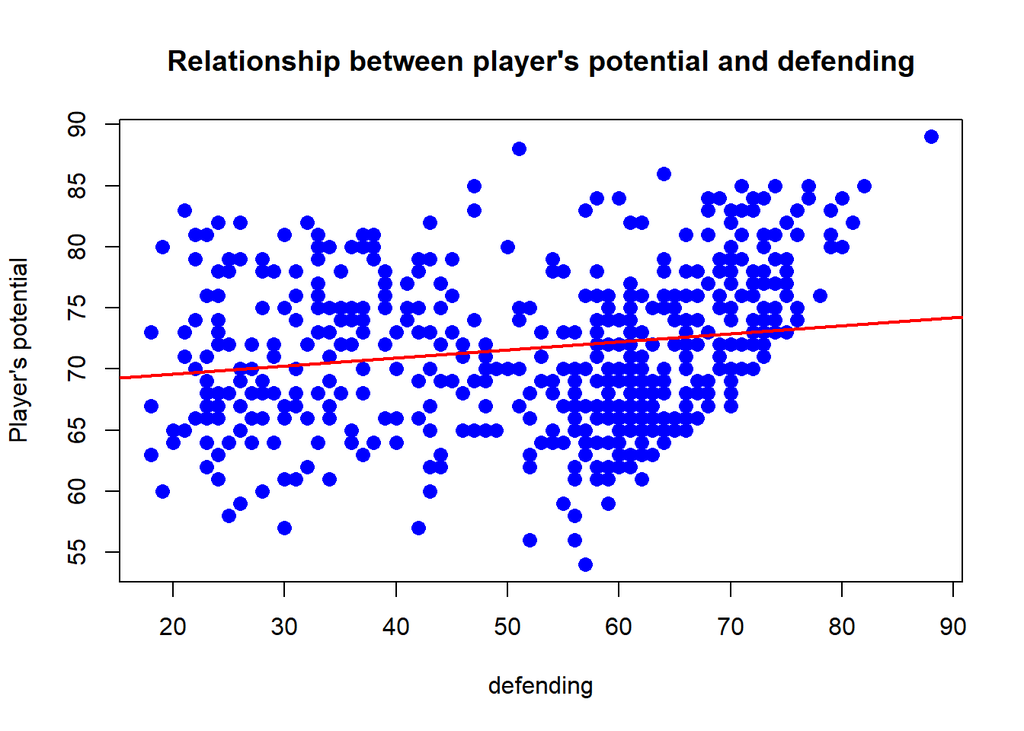

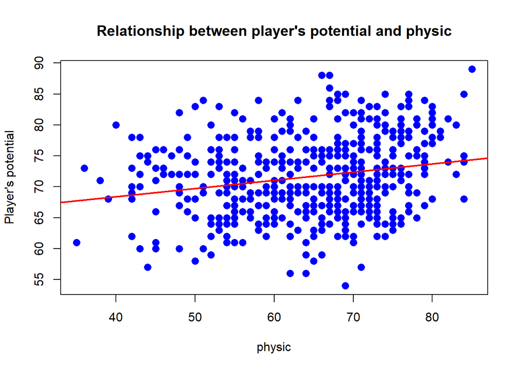

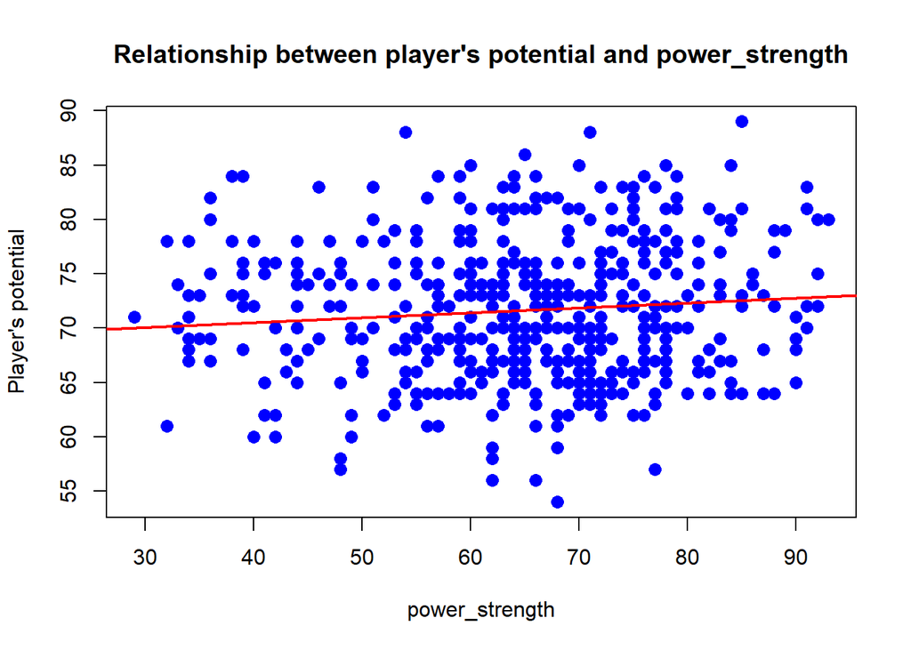

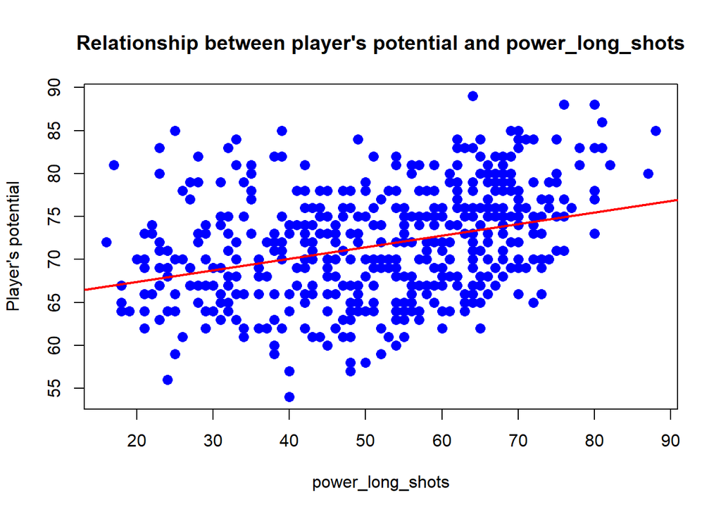

```r
numeric_columns <- c("wage_eur_log",
                     "age",
                     "height_cm",
                     "weight_kg",
                     "pace",
                     "shooting",
                     "passing",
                     "dribbling",
                     "defending",
                     "physic",
                     "power_strength",
                     "power_long_shots")

for (col in numeric_columns){
  title = paste("Relationship between player's potential and", col)
  x_axis = col
  y_axis = "Player's potential"
  plot(df[,col],
       df[,"potential"],
       pch=16,
       cex=1.3,
       col="blue",
       ylab=y_axis,
       xlab=x_axis,
       main=title)

  abline(lm(df[,"potential"]~df[,col]),
         lwd=2,
         col="red")
}
```

Making correlation tests:

```r
for (col in numeric_columns){
  cor_test <- cor.test(df[,col], df[,"potential"], method="spearman", exact=FALSE)
  p_value <- cor_test[3]
  corr_value <- cor_test[4]
  print(p_value)
  if (p_value < 0.05){
    message <- paste("Since, we have a small p-value, we reject the null hypothesis and we say there is a relationship between player's potential and", col, ". The correlation between the 2 variables is", corr_value)
    print(message)
  } else{
    message <- paste("p-value is not small. We failed to reject the null hypothesis. There is no relationship between player's potential and", col)
    print(message)
  }
  cat("---------------------------------------------------------------------\n\n")
}
```

```
## $p.value
## [1] 0.00000000000000000000000000000000004812591
##
## [1] "Since, we have a small p-value, we reject the null hypothesis and we say there is a relationship between player's potential and wage_eur_log . The correlation between the 2 variables is c(rho = 0.507805698417417)"
## ---------------------------------------------------------------------
##
## $p.value
## [1] 0.00000000003466858
##
## [1] "Since, we have a small p-value, we reject the null hypothesis and we say there is a relationship between player's potential and age . The correlation between the 2 variables is c(rho = -0.28676537092926)"
## ---------------------------------------------------------------------
##
## $p.value
## [1] 0.0835688
##
## [1] "p-value is not small. We failed to reject the null hypothesis. There is no relationship between player's potential and height_cm"
## ---------------------------------------------------------------------
##
## $p.value
## [1] 0.06292819
##
## [1] "p-value is not small. We failed to reject the null hypothesis. There is no relationship between player's potential and weight_kg"
## ---------------------------------------------------------------------
##
## $p.value
## [1] 0.00000003994502
##
## [1] "Since, we have a small p-value, we reject the null hypothesis and we say there is a relationship between player's potential and pace . The correlation between the 2 variables is c(rho = 0.239257849172959)"
## ---------------------------------------------------------------------
##
## $p.value
## [1] 0.000000000000003338519
##
## [1] "Since, we have a small p-value, we reject the null hypothesis and we say there is a relationship between player's potential and shooting . The correlation between the 2 variables is c(rho = 0.338008261975809)"
## ---------------------------------------------------------------------
##
## $p.value
## [1] 0.0000000000000000000000001082434
##
## [1] "Since, we have a small p-value, we reject the null hypothesis and we say there is a relationship between player's potential and passing . The correlation between the 2 variables is c(rho = 0.439531262962747)"
```

[output cut: 16 more lines]

```
##
## [1] "Since, we have a small p-value, we reject the null hypothesis and we say there is a relationship between player's potential and physic . The correlation between the 2 variables is c(rho = 0.21543471838648)"
## ---------------------------------------------------------------------
##
## $p.value
## [1] 0.0206317
##
## [1] "Since, we have a small p-value, we reject the null hypothesis and we say there is a relationship between player's potential and power_strength . The correlation between the 2 variables is c(rho = 0.10207686183769)"
## ---------------------------------------------------------------------
##
## $p.value
## [1] 0.000000000000004010964
##
## [1] "Since, we have a small p-value, we reject the null hypothesis and we say there is a relationship between player's potential and power_long_shots . The correlation between the 2 variables is c(rho = 0.337081069986084)"
## ---------------------------------------------------------------------
```

Analyzing relationship between `potential` and `preferred_foot`.

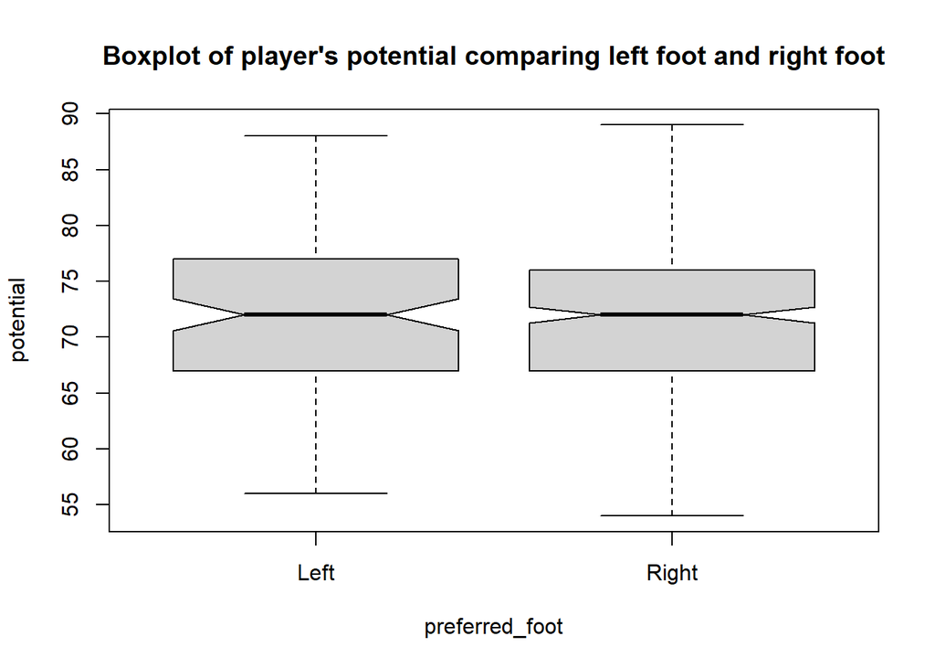

```r
#Anova
boxplot(potential~preferred_foot,
        data=df,
        notch=TRUE,
        main="Boxplot of player's potential comparing left foot and right foot")
```

```r
summary(aov(df$potential~df$preferred_foot))
```

```
##                    Df Sum Sq Mean Sq F value Pr(>F)
## df$preferred_foot   1     65   64.91   1.591  0.208
## Residuals         512  20882   40.78
```

- The boxplot shows that there is not statistical significance in the difference of medians. The ANOVA test shows that there is not statistical significance in the difference of means.